# Complete Block Design II

Prof Randi Garcia  
January 26, 2021

### Reading contemplation question

1. In Kelly's hamster experiment, which factor is *nested* in which other factor? Which two factors are crossed?

### Announcements

- Mini project 1 technical report due now
- HW6 assigned, due on Tuesday
- Quiz 1 due on Thursday 11:55p

### Agenda

- Degrees of freedom in BF[2] design
- Blocking principal
- The Complete Block Design

### Degrees of freedom in BF[2] design

### MP2 Groups

1. What needs to happen next for your study and when/who will do it?
2. When will you actually start collecting data?

### Example - Basic Factorial Design

Modern zoos try to reproduce natural habitats in their exhibits as much as possible. They try to use appropriate plants, but these plants can be infested with inappropriate insects. Cycads (plants that look vaguely like palms) can be infected with mealybugs, and the zoo wishes to test three treatments: 1) water, 2) horticultural oil, and 3) fungal spores in water. Nine infested cycads are taken to the testing area. The number of mealybugs on each tree is counted. The three treatments then get randomly assigned to the three trees each. After three days the mealybugs are counted again. The change in number of mealybugs is computed (\( before-after \)).

### Example

Male albino laboratory rats are used routinely in many kinds of experiments. This experiment was designed to determine the requirements for protein and animo acid threonine in their food. Specifically, the experiment is interested in testing the combinations of eight levels of threonine (.2 through .9% of diet) and five levels of protein (8.68, 12, 15, 18, and 21% of diet). Baby rats were separated into five groups of 40 to form groups of approximately the same weight. The 40 rats in each group were randomly assigned to each of the 40 conditions. Body weight and food consumtption were measured twice weekly, and the average daily weight gain over 21 days was recorded.

### Example - Basic Factorial Design [2]

Male albino laboratory rats are used routinely in many kinds of experiments. This experiment was designed to determine the requirements for protein and animo acid threonine in their food. Specifically, the experiment is interested in testing the combinations of eight levels of threonine (.2 through .9% of diet) and five levels of protein (8.68, 12, 15, 18, and 21% of diet). 200 baby rats were randomly assigned to each of the 40 conditions. Body weight and food consumtption were measured twice weekly, and the average daily weight gain over 21 days was recorded.

### Example

This experiment is interested in the blood consicentration of a drug after it has been administered. The concentration will start at zero, then go up, and back down as it is metabolized. This curve may differ depending on the form of the drug (a solution, a tablet, or a capsule). We will use three subjects, and each subject will be given the drug three times, once for each method. The area under the time-concentration curve is recorded for each subject after each method of drug delivery.

### Example - Basic Factorial Design

This experiment is interested in the blood consicentration of a drug after it has been administered. The concentration will start at zero, then go up, and back down as it is metabolized. This curve may differ depending on the form of the drug (a solution, a tablet, or a capsule). We will use nine subjects, and randomly assign subjects to one of the three delivery methods. The area under the time-concentration curve is recorded for each subject after beging given the drug.

### Design Principal: Blocking

- Blocking is using a factor that is not of research interest – But there may be differences across blocks on the response variable
- A “block” is a level of a blocking factor
- We use blocking to improve precision/statistical power of our factor of interest

### Three Ways to Block

1. Sort units into similar groups
   - Albino rats
2. Subdivide larger chunks of material into sets of smaller peices
   - Mealybug trees
3. Reuse subjects or material in each of sveral times slots
   - Drug study

### Complete Block Desgin, CB[1]

- Experimental material are separated into groups (or reused) to create similar units
- Then each unit within a block is then is assigned one level of the factor of interest
- “Complete Block” means that every block x treatment combination is tested

### Inappropriate Insects

| treatment | tree1 | tree2 | tree3 | tree4 | tree5 |
| --- | --- | --- | --- | --- | --- |
| oil | 4 | 29 | 14 | 14 | 7 |
| spores | -4 | 29 | 4 | -2 | 11 |
| water | -9 | 18 | 10 | 9 | -6 |

Draw the factor diagram, labeling inside outside factors.

### Formal ANOVA for CB[1]

\[ {y}_{ijk}={\mu}+{\tau}_{i}+{\beta}_{j}+{e}_{ijk} \]

| Source | SS | df | MS | F |
| --- | --- | --- | --- | --- |
| Treatment | \( \sum_{i=1}^{a}b(\bar{y}_{i.}-\bar{y}_{..})^{2} \) | \( a-1 \) | \( \frac{{SS}_{T}}{{df}_{T}} \) | \( \frac{{MS}_{T}}{{MS}_{E}} \) |
| Blocks | \( \sum_{j=1}^{b}a(\bar{y}_{.j}-\bar{y}_{..})^{2} \) | \( b-1 \) | \( \frac{{SS}_{B}}{{df}_{B}} \) | \( \frac{{MS}_{B}}{{MS}_{E}} \) |
| Error | \( \sum_{i=1}^{a}\sum_{j=1}^{b}({y}_{ij}-\bar{y}_{i.}-\bar{y}_{.j}+\bar{y}_{..})^{2} \) | \( (a-1)(b-1) \) | \( \frac{{SS}_{E}}{{df}_{E}} \) |  |

### Data Analysis Structure

```r
mealybugs
```

```
    tree treatment bugs_change
1  tree1     water          -9
2  tree1    spores          -4
3  tree1       oil           4
4  tree2     water          18
5  tree2    spores          29
6  tree2       oil          29
7  tree3     water          10
8  tree3    spores           4
9  tree3       oil          14
10 tree4     water           9
11 tree4    spores          -2
12 tree4       oil          14
13 tree5     water          -6
14 tree5    spores          11
15 tree5       oil           7
```

### Formal ANOVA

```r
mod <- lm(bugs_change ~ treatment + tree, data = mealybugs)

anova(mod)
```

```
Analysis of Variance Table

Response: bugs_change
          Df  Sum Sq Mean Sq F value   Pr(>F)
treatment  2  218.13  109.07  2.9963 0.106846
tree       4 1316.40  329.10  9.0412 0.004603 **
Residuals  8  291.20   36.40
---
Signif. codes:  0 '***' 0.001 '**' 0.01 '*' 0.05 '.' 0.1 ' ' 1
```

### Tuplips

A plant breeder wishes to study the effects of soil drainage and variety of tulip bulbs on flower production. Twelve 3m by 10m experimental sites are available in the test garden–each is a .5m deep trench. You can manipulate soil drainage by changing the ratio of sand to clay for the soil you put in a trench. After talking to your collaborator, you decided that four different levels of soil drainage would suffice. You'll be testing 15 different types of tulips, and measuring flower production in the spring.

### Bioequivalence of drug delivery

This experiment is interested in the blood concentration of a drug after it has been administered. The concentration will start at zero, then go up, and back down as it is metabolized. This curve may differ depending on the form of the drug (a solution, a tablet, or a capsule). We will use three subjects, and each subject will be given the drug three times, once for each method. The area under the time-concentration curve is recorded for each subject after each method of drug delivery.

### Latin Square Design

In the bioequivalence example, because the body may adapt to the drug in some way, each drug will be used once in the first period, once in the second period, and once in the third period.

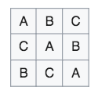